# ML Course

### Assignment - 3

## Student:

1. Idan Noyshul 207813635
2. Sapir Gilany 322358284

## Kaggle

[Kaggle Profile](https://www.kaggle.com/idannoyshul)

[figure not shown]

## Goal

Predict if a passenger survived the sinking of the Titanic or not.

# Key Steps in Titanic Survival Prediction Model

1. **Bootstrap**: the data to create resampled training and testing datasets.
2. **Perform feature selection**: (Forward, Backward, or Hybrid) on the bootstrapped training data.
3. **Cross-Validation (CV)**
4. **Train the classification model**: (KNN, NBC, or LDA) on the selected features.
5. **Confusion Matrix**: Evaluated model performance with true/false positives and negatives.
6. **Key Performance Indicators (KPI)**: Measured metrics such as accuracy, precision, recall, F1-score, and specificity.

```python
# update plotly and pandas_profiling version
!pip install --upgrade plotly
```

```python
# import numpy, matplotlib, etc.
import numpy as np
import pandas as pd
import seaborn as sns
import matplotlib.pyplot as plt

# sklearn imports
from sklearn.metrics import precision_score, recall_score, f1_score ,balanced_accuracy_score
from sklearn.metrics import  roc_auc_score
from sklearn.model_selection import  GridSearchCV
from sklearn.model_selection import train_test_split
from sklearn.compose import ColumnTransformer
from sklearn.preprocessing import StandardScaler, OneHotEncoder
from sklearn.ensemble import BaggingClassifier
from sklearn.linear_model import SGDClassifier
from sklearn.feature_selection import SequentialFeatureSelector
from sklearn.neighbors import KNeighborsClassifier
from sklearn.metrics import  confusion_matrix
from sklearn.naive_bayes import GaussianNB
from sklearn.discriminant_analysis import LinearDiscriminantAnalysis
from sklearn.metrics import accuracy_score, mean_squared_error , log_loss
```

```python
titanic_df = pd.read_csv('train.csv')
```

```python
titanic_df.head(20)
```

|  | PassengerId | Survived | Pclass | Name | Sex | Age | SibSp | Parch | Ticket | Fare | Cabin | Embarked |
| --- | --- | --- | --- | --- | --- | --- | --- | --- | --- | --- | --- | --- |
| 0 | 1 | 0 | 3 | Braund, Mr. Owen Harris | male | 22.0 | 1 | 0 | A/5 21171 | 7.2500 | NaN | S |
| 1 | 2 | 1 | 1 | Cumings, Mrs. John Bradley (Florence Briggs Th... | female | 38.0 | 1 | 0 | PC 17599 | 71.2833 | C85 | C |
| 2 | 3 | 1 | 3 | Heikkinen, Miss. Laina | female | 26.0 | 0 | 0 | STON/O2. 3101282 | 7.9250 | NaN | S |
| 3 | 4 | 1 | 1 | Futrelle, Mrs. Jacques Heath (Lily May Peel) | female | 35.0 | 1 | 0 | 113803 | 53.1000 | C123 | S |
| 4 | 5 | 0 | 3 | Allen, Mr. William Henry | male | 35.0 | 0 | 0 | 373450 | 8.0500 | NaN | S |
| 5 | 6 | 0 | 3 | Moran, Mr. James | male | NaN | 0 | 0 | 330877 | 8.4583 | NaN | Q |
| 6 | 7 | 0 | 1 | McCarthy, Mr. Timothy J | male | 54.0 | 0 | 0 | 17463 | 51.8625 | E46 | S |
| 7 | 8 | 0 | 3 | Palsson, Master. Gosta Leonard | male | 2.0 | 3 | 1 | 349909 | 21.0750 | NaN | S |
| 8 | 9 | 1 | 3 | Johnson, Mrs. Oscar W (Elisabeth Vilhelmina Berg) | female | 27.0 | 0 | 2 | 347742 | 11.1333 | NaN | S |
| 9 | 10 | 1 | 2 | Nasser, Mrs. Nicholas (Adele Achem) | female | 14.0 | 1 | 0 | 237736 | 30.0708 | NaN | C |
| 10 | 11 | 1 | 3 | Sandstrom, Miss. Marguerite Rut | female | 4.0 | 1 | 1 | PP 9549 | 16.7000 | G6 | S |
| 11 | 12 | 1 | 1 | Bonnell, Miss. Elizabeth | female | 58.0 | 0 | 0 | 113783 | 26.5500 | C103 | S |
| 12 | 13 | 0 | 3 | Saundercock, Mr. William Henry | male | 20.0 | 0 | 0 | A/5. 2151 | 8.0500 | NaN | S |
| 13 | 14 | 0 | 3 | Andersson, Mr. Anders Johan | male | 39.0 | 1 | 5 | 347082 | 31.2750 | NaN | S |
| 14 | 15 | 0 | 3 | Vestrom, Miss. Hulda Amanda Adolfina | female | 14.0 | 0 | 0 | 350406 | 7.8542 | NaN | S |
| 15 | 16 | 1 | 2 | Hewlett, Mrs. (Mary D Kingcome) | female | 55.0 | 0 | 0 | 248706 | 16.0000 | NaN | S |
| 16 | 17 | 0 | 3 | Rice, Master. Eugene | male | 2.0 | 4 | 1 | 382652 | 29.1250 | NaN | Q |
| 17 | 18 | 1 | 2 | Williams, Mr. Charles Eugene | male | NaN | 0 | 0 | 244373 | 13.0000 | NaN | S |
| 18 | 19 | 0 | 3 | Vander Planke, Mrs. Julius (Emelia Maria Vande... | female | 31.0 | 1 | 0 | 345763 | 18.0000 | NaN | S |
| 19 | 20 | 1 | 3 | Masselmani, Mrs. Fatima | female | NaN | 0 | 0 | 2649 | 7.2250 | NaN | C |

```python
titanic_df.keys()
```

```
Index(['PassengerId', 'Survived', 'Pclass', 'Name', 'Sex', 'Age', 'SibSp',
       'Parch', 'Ticket', 'Fare', 'Cabin', 'Embarked'],
      dtype='object')
```

```python
display(titanic_df)
```

|  | PassengerId | Survived | Pclass | Name | Sex | Age | SibSp | Parch | Ticket | Fare | Cabin | Embarked |
| --- | --- | --- | --- | --- | --- | --- | --- | --- | --- | --- | --- | --- |
| 0 | 1 | 0 | 3 | Braund, Mr. Owen Harris | male | 22.0 | 1 | 0 | A/5 21171 | 7.2500 | NaN | S |
| 1 | 2 | 1 | 1 | Cumings, Mrs. John Bradley (Florence Briggs Th... | female | 38.0 | 1 | 0 | PC 17599 | 71.2833 | C85 | C |
| 2 | 3 | 1 | 3 | Heikkinen, Miss. Laina | female | 26.0 | 0 | 0 | STON/O2. 3101282 | 7.9250 | NaN | S |
| 3 | 4 | 1 | 1 | Futrelle, Mrs. Jacques Heath (Lily May Peel) | female | 35.0 | 1 | 0 | 113803 | 53.1000 | C123 | S |
| 4 | 5 | 0 | 3 | Allen, Mr. William Henry | male | 35.0 | 0 | 0 | 373450 | 8.0500 | NaN | S |
| ... | ... | ... | ... | ... | ... | ... | ... | ... | ... | ... | ... | ... |
| 886 | 887 | 0 | 2 | Montvila, Rev. Juozas | male | 27.0 | 0 | 0 | 211536 | 13.0000 | NaN | S |
| 887 | 888 | 1 | 1 | Graham, Miss. Margaret Edith | female | 19.0 | 0 | 0 | 112053 | 30.0000 | B42 | S |
| 888 | 889 | 0 | 3 | Johnston, Miss. Catherine Helen "Carrie" | female | NaN | 1 | 2 | W./C. 6607 | 23.4500 | NaN | S |
| 889 | 890 | 1 | 1 | Behr, Mr. Karl Howell | male | 26.0 | 0 | 0 | 111369 | 30.0000 | C148 | C |
| 890 | 891 | 0 | 3 | Dooley, Mr. Patrick | male | 32.0 | 0 | 0 | 370376 | 7.7500 | NaN | Q |

891 rows × 12 columns

```python
titanic_df.describe()
```

|  | PassengerId | Survived | Pclass | Age | SibSp | Parch | Fare |
| --- | --- | --- | --- | --- | --- | --- | --- |
| count | 891.000000 | 891.000000 | 891.000000 | 714.000000 | 891.000000 | 891.000000 | 891.000000 |
| mean | 446.000000 | 0.383838 | 2.308642 | 29.699118 | 0.523008 | 0.381594 | 32.204208 |
| std | 257.353842 | 0.486592 | 0.836071 | 14.526497 | 1.102743 | 0.806057 | 49.693429 |
| min | 1.000000 | 0.000000 | 1.000000 | 0.420000 | 0.000000 | 0.000000 | 0.000000 |
| 25% | 223.500000 | 0.000000 | 2.000000 | 20.125000 | 0.000000 | 0.000000 | 7.910400 |
| 50% | 446.000000 | 0.000000 | 3.000000 | 28.000000 | 0.000000 | 0.000000 | 14.454200 |
| 75% | 668.500000 | 1.000000 | 3.000000 | 38.000000 | 1.000000 | 0.000000 | 31.000000 |
| max | 891.000000 | 1.000000 | 3.000000 | 80.000000 | 8.000000 | 6.000000 | 512.329200 |

### Titanic Survival Summary

- **Number of survivors**: **342**
- **Percentage of survivors**: **38.38%**

This analysis indicates that approximately **38.38%** of the passengers survived the Titanic disaster, totaling **342 survivors**.

```python
# Count total survivors
num_survived = titanic_df['Survived'].sum()

# Calculate the percentage of survivors
total_passengers = titanic_df.shape[0]
percentage_survived = (num_survived / total_passengers) * 100

print(f"Number of survivors: {num_survived}")
print(f"Percentage of survivors: {percentage_survived:.2f}%")
```

```
Number of survivors: 342
Percentage of survivors: 38.38%
```

```python
titanic_df.dtypes
```

```
PassengerId      int64
Survived         int64
Pclass           int64
Name            object
Sex             object
Age            float64
SibSp            int64
Parch            int64
Ticket          object
Fare           float64
Cabin           object
Embarked        object
dtype: object
```

The dataset contains both numeric and object features. For the purpose of modeling, we assume that the `Name` feature does not provide significant predictive value and can be removed from the model.

## Data Visualization

We want to:

- See how the target depends on each feature
- Detect the most meaningful features in this dataset.

### Investigation 'Survived' Column:

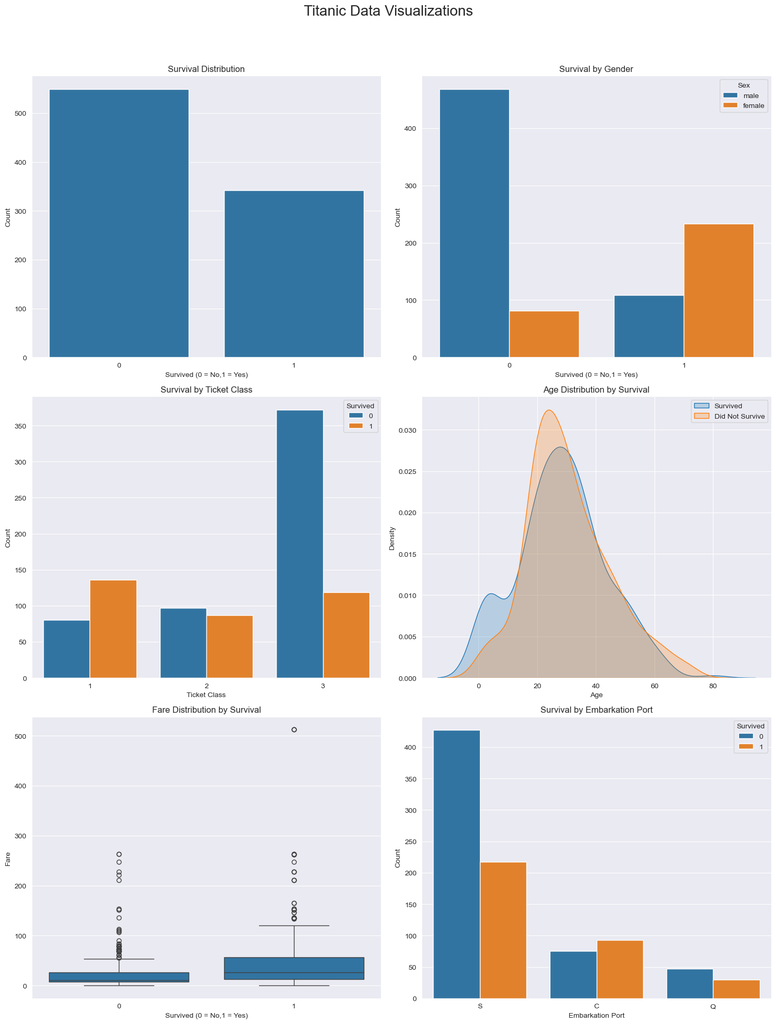

```python
# Create a figure with subplots arranged in a grid
fig, axes = plt.subplots(3, 2, figsize=(15, 20))
fig.suptitle('Titanic Data Visualizations', fontsize=20)

# 1. Survival Distribution
sns.countplot(x='Survived', data=titanic_df, ax=axes[0, 0])
axes[0, 0].set_title('Survival Distribution')
axes[0, 0].set_xlabel('Survived (0 = No,1 = Yes)')
axes[0, 0].set_ylabel('Count')

# 2. Survival Rate by Gender
sns.countplot(x='Survived', hue='Sex', data=titanic_df, ax=axes[0, 1])
axes[0, 1].set_title('Survival by Gender')
axes[0, 1].set_xlabel('Survived (0 = No,1 = Yes)')
axes[0, 1].set_ylabel('Count')

# 3. Survival Rate by Class
sns.countplot(x='Pclass', hue='Survived', data=titanic_df, ax=axes[1, 0])
axes[1, 0].set_title('Survival by Ticket Class')
axes[1, 0].set_xlabel('Ticket Class')
axes[1, 0].set_ylabel('Count')

# 4. Age Distribution of Survivors
sns.kdeplot(titanic_df.loc[titanic_df['Survived'] == 1, 'Age'], label='Survived', fill=True, ax=axes[1, 1])
sns.kdeplot(titanic_df.loc[titanic_df['Survived'] == 0, 'Age'], label='Did Not Survive', fill=True, ax=axes[1, 1])
axes[1, 1].set_title('Age Distribution by Survival')
axes[1, 1].set_xlabel('Age')
axes[1, 1].set_ylabel('Density')
axes[1, 1].legend()

# 5. Fare Distribution
sns.boxplot(x='Survived', y='Fare', data=titanic_df, ax=axes[2, 0])
axes[2, 0].set_title('Fare Distribution by Survival')
axes[2, 0].set_xlabel('Survived (0 = No,1 = Yes)')
axes[2, 0].set_ylabel('Fare')

# 6. Embarkation and Survival
sns.countplot(x='Embarked', hue='Survived', data=titanic_df, ax=axes[2, 1])
axes[2, 1].set_title('Survival by Embarkation Port')
axes[2, 1].set_xlabel('Embarkation Port')
axes[2, 1].set_ylabel('Count')

# Adjust layout to prevent overlapping
plt.tight_layout(rect=[0, 0, 1, 0.95])  # Adjust for suptitle
plt.show()
```

[output not shown]

### Conclusion

Survival on the Titanic was strongly influenced by socioeconomic factors and prioritization during rescue efforts:

1. **Embarkation & Class**: First-class passengers, especially from Cherbourg, had the highest survival rates, while third-class passengers, mainly from Southampton and Queenstown, faced significant disadvantages.
2. **Fare**: Higher fares were associated with better survival chances, reflecting the advantages of wealth and class.
3. **Gender**: Females had a clear survival advantage due to evacuation priorities, with most non-survivors being male.
4. **Age**: Children were prioritized during rescue, leading to high survival rates, while young adults faced the greatest challenges in survival.

These factors highlight the significant role of class, gender, and age in determining survival chances during the Titanic disaster.

### Create the FamilySize Column

Formula: `FamilySize = SibSp + Parch + 1`

1. **Family Dynamics**: Helps analyze the impact of traveling with family on survival chances.
2. **Inclusive Count**: Includes the passenger themselves in the family size.
3. **Feature Engineering**: Combines `SibSp` and `Parch` into a single, more informative feature for analysis and modeling.

This column provides insights into survival trends based on family size.

```python
titanic_df['FamilySize'] = titanic_df['SibSp'] + titanic_df['Parch'] + 1
```

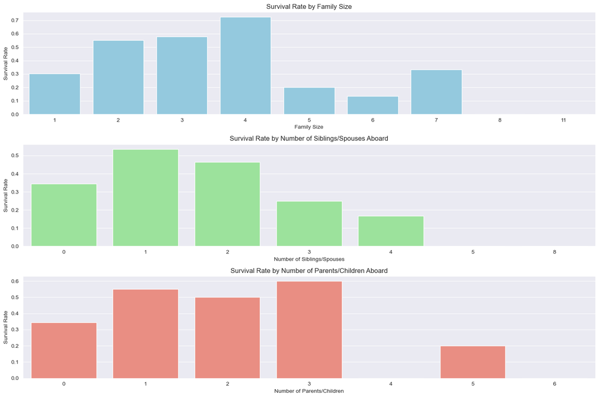

```python
plt.figure(figsize=(15, 10))

# 1. Survival rate by FamilySize
plt.subplot(3, 1, 1)
sns.barplot(x='FamilySize', y='Survived', data=titanic_df, errorbar=None, color='skyblue')
plt.title('Survival Rate by Family Size')
plt.xlabel('Family Size')
plt.ylabel('Survival Rate')

# 2. Survival rate by SibSp
plt.subplot(3, 1, 2)
sns.barplot(x='SibSp', y='Survived', data=titanic_df, errorbar=None, color='lightgreen')
plt.title('Survival Rate by Number of Siblings/Spouses Aboard')
plt.xlabel('Number of Siblings/Spouses')
plt.ylabel('Survival Rate')

# 3. Survival rate by Parch
plt.subplot(3, 1, 3)
sns.barplot(x='Parch', y='Survived', data=titanic_df, errorbar=None, color='salmon')
plt.title('Survival Rate by Number of Parents/Children Aboard')
plt.xlabel('Number of Parents/Children')
plt.ylabel('Survival Rate')

# Adjust layout and display
plt.tight_layout()
plt.show()
```

### Insights from Family Size, SibSp, and Parch

1. **Small Families Survive More**: Families of 2-4 members had the highest survival rates.
2. **Large Families Struggle**: Survival drops significantly for families with 5+ members.
3. **Traveling Alone is Risky**: Passengers with no family onboard had lower survival chances.
4. **Balanced Support**: Small groups provided optimal support and evacuation feasibility.

### Conclusion

Small to medium family groups had the best survival chances, while larger families and solo travelers faced significant disadvantages.

## Preprocessing

### Checking for missing values

Identify columns with missing data and decide how to handle them by filling with appropriate values (e.g., median) or dropping if necessary.

```python
titanic_df.isna().any() # check if there are Nan values
```

```
PassengerId    False
Survived       False
Pclass         False
Name           False
Sex            False
Age             True
SibSp          False
Parch          False
Ticket         False
Fare           False
Cabin           True
Embarked        True
FamilySize     False
dtype: bool
```

According to the table we can notice that `Age` , `Cabin` contains Nan's.

```python
titanic_df.info()
```

```
<class 'pandas.core.frame.DataFrame'>
RangeIndex: 891 entries, 0 to 890
Data columns (total 13 columns):
 #   Column       Non-Null Count  Dtype
---  ------       --------------  -----
 0   PassengerId  891 non-null    int64
 1   Survived     891 non-null    int64
 2   Pclass       891 non-null    int64
 3   Name         891 non-null    object
 4   Sex          891 non-null    object
 5   Age          714 non-null    float64
 6   SibSp        891 non-null    int64
 7   Parch        891 non-null    int64
 8   Ticket       891 non-null    object
 9   Fare         891 non-null    float64
 10  Cabin        204 non-null    object
 11  Embarked     889 non-null    object
 12  FamilySize   891 non-null    int64
dtypes: float64(2), int64(6), object(5)
memory usage: 90.6+ KB
```

```python
titanic_df['Cabin']
```

```
0       NaN
1       C85
2       NaN
3      C123
4       NaN
       ...
886     NaN
887     B42
888     NaN
889    C148
890     NaN
Name: Cabin, Length: 891, dtype: object
```

### Handling Missing Values: Age

- Missing values in the `Age` column are filled with the **median**.
- This approach provides a central value for missing entries without being influenced by extreme ages.

```python
# Check for missing values in the Age column
print(f"Number of missing values in 'Age': {titanic_df['Age'].isnull().sum()}")

# Fill missing values in Age with the median and reassign to the column
titanic_df['Age'] = titanic_df['Age'].fillna(titanic_df['Age'].median())

# Verify that missing values are handled
print(f"Number of missing values in 'Age' after filling: {titanic_df['Age'].isnull().sum()}")
```

```
Number of missing values in 'Age': 177
Number of missing values in 'Age' after filling: 0
```

## Drop `Cabin` Column

```python
titanic_df.drop('Cabin', axis=1, inplace=True)
```

```python
titanic_df.info()
```

```
<class 'pandas.core.frame.DataFrame'>
RangeIndex: 891 entries, 0 to 890
Data columns (total 12 columns):
 #   Column       Non-Null Count  Dtype
---  ------       --------------  -----
 0   PassengerId  891 non-null    int64
 1   Survived     891 non-null    int64
 2   Pclass       891 non-null    int64
 3   Name         891 non-null    object
 4   Sex          891 non-null    object
 5   Age          891 non-null    float64
 6   SibSp        891 non-null    int64
 7   Parch        891 non-null    int64
 8   Ticket       891 non-null    object
 9   Fare         891 non-null    float64
 10  Embarked     889 non-null    object
 11  FamilySize   891 non-null    int64
dtypes: float64(2), int64(6), object(4)
memory usage: 83.7+ KB
```

### Handling Missing Values: Embarked

- **Issue**: `Embarked` has 2 missing values.
- **Solution**: Impute missing values with the **most frequent value (mode)**.
- **Reason**: The mode minimizes bias and preserves the dataset structure with minimal impact.

```python
# Check the number of missing values in Embarked
print(f"Number of missing values in 'Embarked': {titanic_df['Embarked'].isnull().sum()}")

# Find the most frequent value (mode)
most_frequent_embarked = titanic_df['Embarked'].mode()[0]
print(f"Most frequent value in 'Embarked': {most_frequent_embarked}")

# Fill missing values in Embarked with the mode
titanic_df['Embarked'] = titanic_df['Embarked'].fillna(most_frequent_embarked)

# Verify that missing values are handled
print(f"Number of missing values in 'Embarked' after filling: {titanic_df['Embarked'].isnull().sum()}")
```

```
Number of missing values in 'Embarked': 2
Most frequent value in 'Embarked': S
Number of missing values in 'Embarked' after filling: 0
```

```python
print(titanic_df.isnull().sum())
```

```
PassengerId    0
Survived       0
Pclass         0
Name           0
Sex            0
Age            0
SibSp          0
Parch          0
Ticket         0
Fare           0
Embarked       0
FamilySize     0
dtype: int64
```

### Handling the Name Column: Extracting Titles

Create a `Title` column from Name (e.g., `Mr`, `Mrs`, `Miss`) to capture social status.

```python
# Extract all titles from the Name column into a new column 'Title'
titanic_df['Title'] = titanic_df['Name'].str.extract(r' ([A-Za-z]+)\.', expand=False)

# Display the unique titles
print(f"Unique titles extracted: {titanic_df['Title'].unique()}")
```

```
Unique titles extracted: ['Mr' 'Mrs' 'Miss' 'Master' 'Don' 'Rev' 'Dr' 'Mme' 'Ms' 'Major' 'Lady'
 'Sir' 'Mlle' 'Col' 'Capt' 'Countess' 'Jonkheer']
```

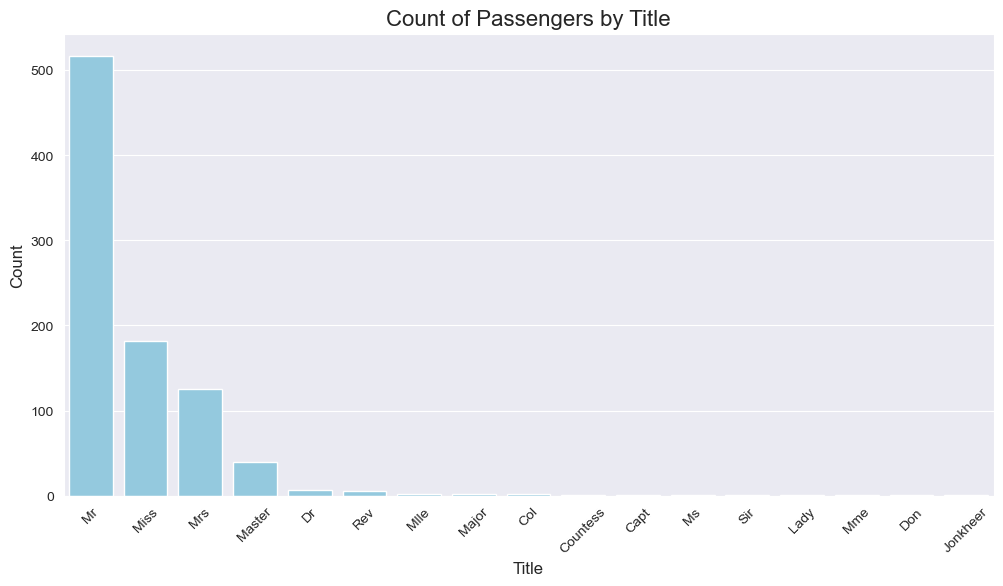

```python
plt.figure(figsize=(12, 6))
sns.countplot(
    x='Title',
    data=titanic_df,
    order=titanic_df['Title'].value_counts().index,
    color='skyblue'
)
plt.title('Count of Passengers by Title', fontsize=16)
plt.xlabel('Title', fontsize=12)
plt.ylabel('Count', fontsize=12)
plt.xticks(rotation=45)
plt.show()
```

## Group Rare `Titles`:

Combines uncommon titles (e.g., `Lady`, `Sir`, `Jonkheer`) into a single Rare category.

```python
titanic_df.drop('Title', axis=1, inplace=True)
# Extract titles from the Name column
titanic_df['Title'] = titanic_df['Name'].str.extract(r' ([A-Za-z]+)\.', expand=False)

# Group rare titles into 'Rare' and standardize common ones
titanic_df['Title'] = titanic_df['Title'].replace(
    ['Lady', 'Countess', 'Capt', 'Col', 'Don', 'Dr', 'Major', 'Rev', 'Sir', 'Jonkheer', 'Dona', 'Professor'], 'Rare'
)
titanic_df['Title'] = titanic_df['Title'].replace(['Mlle', 'Ms'], 'Miss')
titanic_df['Title'] = titanic_df['Title'].replace('Mme', 'Mrs')

# Verify the grouped titles
print(titanic_df['Title'].value_counts())
```

```
Title
Mr        517
Miss      185
Mrs       126
Master     40
Rare       23
Name: count, dtype: int64
```

### Drop `Name`:

The Name column is no longer useful after extracting Title

```python
titanic_df.drop('Name', axis=1, inplace=True)
```

## Handling the `Ticket` Column: Extracting Prefix

```python
titanic_df.dtypes
```

```
PassengerId      int64
Survived         int64
Pclass           int64
Sex             object
Age            float64
SibSp            int64
Parch            int64
Ticket          object
Fare           float64
Embarked        object
FamilySize       int64
Title           object
dtype: object
```

```python
categorical_columns = titanic_df.select_dtypes(include=['object']).columns
print(f"Categorical columns: {categorical_columns.tolist()}")
```

```
Categorical columns: ['Sex', 'Ticket', 'Embarked', 'Title']
```

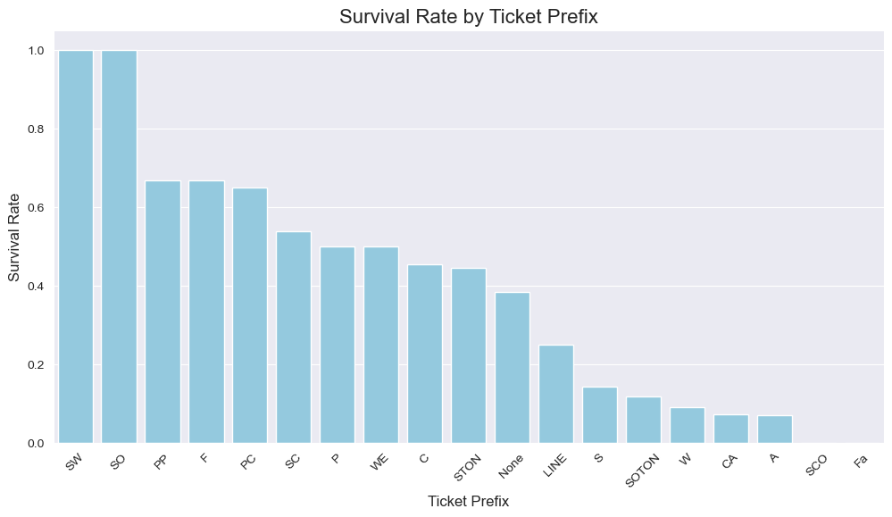

```python
# Extract ticket prefixes
titanic_df['Ticket_Prefix'] = titanic_df['Ticket'].str.extract(r'([A-Za-z]+)', expand=False)
titanic_df['Ticket_Prefix'] = titanic_df['Ticket_Prefix'].fillna('None')

# Group by Ticket_Prefix and calculate survival rates
prefix_survival = titanic_df.groupby('Ticket_Prefix')['Survived'].mean().sort_values(ascending=False)

# Visualize survival rates for prefixes
plt.figure(figsize=(12, 6))
sns.barplot(x=prefix_survival.index, y=prefix_survival.values, color='skyblue')
plt.title('Survival Rate by Ticket Prefix', fontsize=16)
plt.xlabel('Ticket Prefix', fontsize=12)
plt.ylabel('Survival Rate', fontsize=12)
plt.xticks(rotation=45)
plt.show()
```

```python
# Count the number of passengers in each Ticket_Prefix group
ticket_group_counts = titanic_df['Ticket_Prefix'].value_counts()

# Display the counts
print(ticket_group_counts)
```

```
Ticket_Prefix
None     661
PC        60
C         33
A         29
STON      18
SOTON     17
S         14
CA        14
SC        13
W         11
F          6
LINE       4
PP         3
P          2
WE         2
SW         1
SCO        1
Fa         1
SO         1
Name: count, dtype: int64
```

### Dropping the Ticket Column

- **Irrelevance**: The `Ticket_Prefix` distribution shows most values (e.g., `None`) are overrepresented, while many prefixes (e.g., `SW`, `SO`, `Fa`) have very few occurrences, making them statistically insignificant.
- **Complexity**: Encoding this feature introduces unnecessary complexity without clear value.

### Conclusion

The `Ticket` column and its derived `Ticket_Prefix` will be dropped to simplify the dataset and focus on more relevant features.

```python
titanic_df.drop('Ticket_Prefix', axis=1, inplace=True)
titanic_df.drop('Ticket', axis=1, inplace=True)
```

### Titanic Data Preprocessing

1. **Set Index**:
   - Set `PassengerId` as the index and drop it from features.
2. **Split Features and Label**:
   - `X` (features): All columns except `Survived`.
   - `y` (label): The `Survived` column.
3. **Create Preprocessing Pipeline**:
   - Standardize numeric columns using `StandardScaler`.
   - One-Hot Encode categorical columns with `OneHotEncoder`.
4. **Split Data**:
   - Split into training and testing sets (80%-20%).

```python
titanic_df.dtypes
```

```
PassengerId      int64
Survived         int64
Pclass           int64
Sex             object
Age            float64
SibSp            int64
Parch            int64
Fare           float64
Embarked        object
FamilySize       int64
Title           object
dtype: object
```

```python
# Step 1: Split features and target
X = titanic_df.drop(columns=['Survived', 'PassengerId'])
y = titanic_df['Survived']

# Step 2: Identify numerical and categorical columns
numerical_cols = X.select_dtypes(include=['int64', 'float64']).columns.tolist()
categorical_cols = X.select_dtypes(include=['object', 'bool']).columns.tolist()

# Step 3: Create a ColumnTransformer for encoding and scaling
ct_enc_std = ColumnTransformer(
    transformers=[
        ("encoding", OneHotEncoder(handle_unknown='ignore'), categorical_cols),
        ("standard", StandardScaler(), numerical_cols)
    ]
)

# Step 4: Apply transformations
X_transformed = ct_enc_std.fit_transform(X)

# Get feature names after One-Hot Encoding and Scaling
encoded_feature_names = (
    ct_enc_std.named_transformers_["encoding"]
    .get_feature_names_out(categorical_cols)
    .tolist() + numerical_cols
)

# Convert transformed data to a DataFrame with correct column names
X_encoded = pd.DataFrame(X_transformed, columns=encoded_feature_names)
```

## Bootstrap

```python
# Step 5: Define the BaggingClassifier
bagging_model = BaggingClassifier(
    estimator=SGDClassifier(random_state=1),  # Base model
    bootstrap=True,  # Enable bootstrapping
    random_state=1,   # For reproducibility
)

# Step 6: Define the parameter grid for `n_estimators`
param_grid = {
    'n_estimators': [10, 20, 30, 40, 50]  # Test these values for the number of estimators
}

# Step 7: Use GridSearchCV to find the best `n_estimators`
grid_search = GridSearchCV(
    estimator=bagging_model,
    param_grid=param_grid,
    cv=7,  # 7-fold cross-validation
    scoring='accuracy',  # Optimize for accuracy
    return_train_score=True,
    n_jobs=-1  # Use all available processors
)

# Fit the GridSearchCV on the transformed dataset
grid_search.fit(X_encoded, y)
best_estimator = grid_search.best_params_['n_estimators']
# Step 8: Output the best parameters and score
print(f"Best n_estimators: {best_estimator}")
print(f"Best cross-validation accuracy: {grid_search.best_score_:.4f}")
```

```
Best n_estimators: 10
Best cross-validation accuracy: 0.8193
```

### Cross-Validation Results

| `cv` Value | Best `n_estimators` | Best Cross-Validation Accuracy |
| --- | --- | --- |
| 7 | 10 | **0.8193** (highest) |
| 10 | 50 | 0.8115 |
| 5 | 40 | 0.8058 |

### Summary

- Use `cv=7` for cross-validation.
- Set `n_estimators=10` for optimal performance.

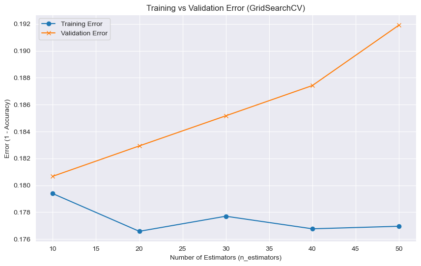

```python
train_scores = grid_search.cv_results_['mean_train_score']  # Mean training accuracy
val_scores = grid_search.cv_results_['mean_test_score']  # Mean validation accuracy
n_estimators_values = param_grid['n_estimators']

train_errors = 1 - np.array(train_scores)
val_errors = 1 - np.array(val_scores)

plt.figure(figsize=(10, 6))
plt.plot(n_estimators_values, train_errors, label='Training Error', marker='o')
plt.plot(n_estimators_values, val_errors, label='Validation Error', marker='x')
plt.xlabel('Number of Estimators (n_estimators)')
plt.ylabel('Error (1 - Accuracy)')
plt.title('Training vs Validation Error (GridSearchCV)')
plt.legend()
plt.grid(True)
plt.show()
```

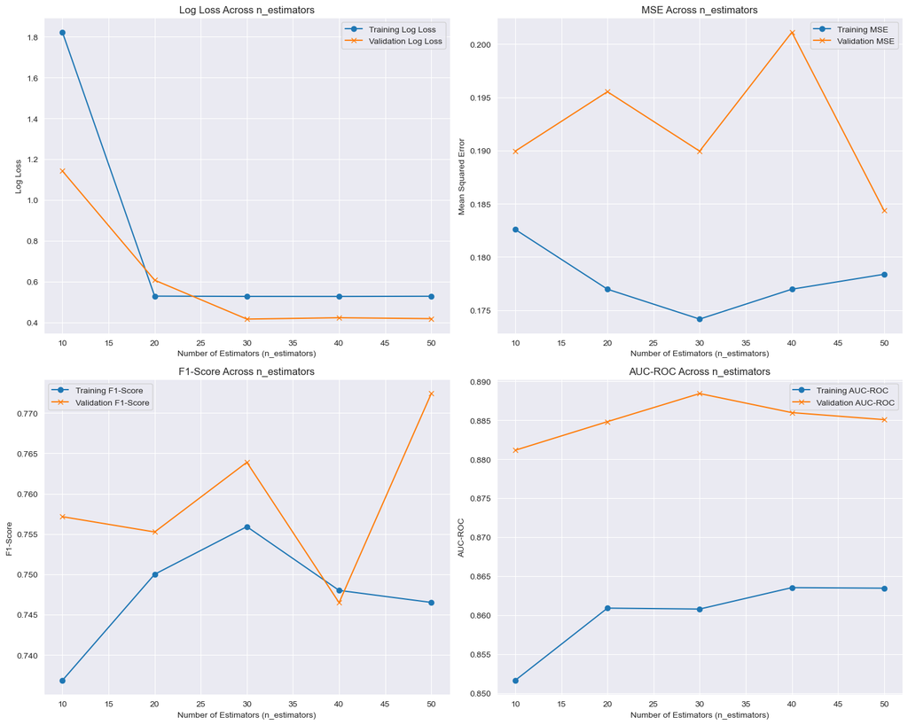

```python
# Initialize lists to store metrics for each n_estimator value
train_log_losses = []
val_log_losses = []
train_mse = []
val_mse = []
train_f1_scores = []
val_f1_scores = []
train_roc_aucs = []
val_roc_aucs = []

X_train, X_test, y_train, y_test = train_test_split(X_encoded, y, test_size=0.2, random_state=42)

# Loop through each n_estimators value in the parameter grid
for n_estimators in param_grid['n_estimators']:
    # Update the BaggingClassifier with the current n_estimators
    bagging_model = BaggingClassifier(
        estimator=SGDClassifier(random_state=1),
        n_estimators=n_estimators,
        bootstrap=True,
        random_state=1,
    )
    # Fit the model on the training set
    bagging_model.fit(X_train, y_train)

    # Predict probabilities and classes for training and validation
    y_train_prob = bagging_model.predict_proba(X_train)
    y_val_prob = bagging_model.predict_proba(X_test)
    y_train_pred = bagging_model.predict(X_train)
    y_val_pred = bagging_model.predict(X_test)

    # Calculate Log Loss
    train_log_losses.append(log_loss(y_train, y_train_prob))
    val_log_losses.append(log_loss(y_test, y_val_prob))

    # Calculate MSE
    train_mse.append(mean_squared_error(y_train, y_train_pred))
    val_mse.append(mean_squared_error(y_test, y_val_pred))

    # Calculate F1-Score
    train_f1_scores.append(f1_score(y_train, y_train_pred))
    val_f1_scores.append(f1_score(y_test, y_val_pred))

    # Calculate AUC-ROC
    train_roc_aucs.append(roc_auc_score(y_train, y_train_prob[:, 1]))
    val_roc_aucs.append(roc_auc_score(y_test, y_val_prob[:, 1]))

# Define the number of rows and columns for subplots
fig, axes = plt.subplots(2, 2, figsize=(15, 12))

# Plot Log Loss
axes[0, 0].plot(param_grid['n_estimators'], train_log_losses, label='Training Log Loss', marker='o')
axes[0, 0].plot(param_grid['n_estimators'], val_log_losses, label='Validation Log Loss', marker='x')
axes[0, 0].set_xlabel('Number of Estimators (n_estimators)')
axes[0, 0].set_ylabel('Log Loss')
axes[0, 0].set_title('Log Loss Across n_estimators')
axes[0, 0].legend()
axes[0, 0].grid(True)

# Plot MSE
axes[0, 1].plot(param_grid['n_estimators'], train_mse, label='Training MSE', marker='o')
axes[0, 1].plot(param_grid['n_estimators'], val_mse, label='Validation MSE', marker='x')
axes[0, 1].set_xlabel('Number of Estimators (n_estimators)')
axes[0, 1].set_ylabel('Mean Squared Error')
axes[0, 1].set_title('MSE Across n_estimators')
axes[0, 1].legend()
axes[0, 1].grid(True)

# Plot F1-Score
axes[1, 0].plot(param_grid['n_estimators'], train_f1_scores, label='Training F1-Score', marker='o')
axes[1, 0].plot(param_grid['n_estimators'], val_f1_scores, label='Validation F1-Score', marker='x')
axes[1, 0].set_xlabel('Number of Estimators (n_estimators)')
axes[1, 0].set_ylabel('F1-Score')
axes[1, 0].set_title('F1-Score Across n_estimators')
axes[1, 0].legend()
axes[1, 0].grid(True)

# Plot AUC-ROC
axes[1, 1].plot(param_grid['n_estimators'], train_roc_aucs, label='Training AUC-ROC', marker='o')
axes[1, 1].plot(param_grid['n_estimators'], val_roc_aucs, label='Validation AUC-ROC', marker='x')
axes[1, 1].set_xlabel('Number of Estimators (n_estimators)')
axes[1, 1].set_ylabel('AUC-ROC')
axes[1, 1].set_title('AUC-ROC Across n_estimators')
axes[1, 1].legend()
axes[1, 1].grid(True)

# Adjust layout for better spacing
plt.tight_layout()
plt.show()
```

```python
# Define the base model
base_model = BaggingClassifier(
    estimator=SGDClassifier(random_state=1),
    n_estimators=best_estimator,  # Best n_estimators from previous step
    bootstrap=True,
    random_state=1
)
```

## Feature Selection

Perform feature selection (Forward, Backward, or Hybrid) on the bootstrapped training data.

```python
# Total number of features in the dataset
n_features_total = X_encoded.shape[1]
n_features_to_select = n_features_total // 2  # Select half of the features

# Backward Feature Selection
print("Performing Backward Feature Selection...")
backward_selector = SequentialFeatureSelector(
    base_model,
    n_features_to_select=n_features_to_select,
    direction="backward",
    scoring="accuracy",
    cv=5,
    n_jobs=-1
)
backward_selector.fit(X_encoded, y)
backward_features = backward_selector.get_support(indices=True)
print(f"Backward selected features: {backward_features}")

# Forward Feature Selection
print("Performing Forward Feature Selection...")
forward_selector = SequentialFeatureSelector(
    base_model,
    n_features_to_select=n_features_to_select,
    direction="forward",
    scoring="accuracy",
    cv=5,
    n_jobs=-1
)
forward_selector.fit(X_encoded, y)
forward_features = forward_selector.get_support(indices=True)
print(f"Forward selected features: {forward_features}")
```

```
Performing Backward Feature Selection...
Backward selected features: [ 0  2  4  5  7 10 11 15]
Performing Forward Feature Selection...
Forward selected features: [ 0  1  2  5  8  9 10 15]
```

```python
print("Performing Hybrid Feature Selection...")
# Step 1: Forward Selection to Narrow Down Features
hybrid_forward_selector = SequentialFeatureSelector(
    base_model,
    n_features_to_select=n_features_to_select,  # Start with a reduced subset
    direction="forward",
    scoring="accuracy",
    cv=5,
    n_jobs=-1
)
hybrid_forward_selector.fit(X_encoded, y)
forward_selected_features = hybrid_forward_selector.get_support(indices=True)

# Step 2: Backward Selection to Refine Features
# Use the features selected by forward selection
X_forward_selected = X_encoded.iloc[:, forward_selected_features]

hybrid_backward_selector = SequentialFeatureSelector(
    base_model,
    n_features_to_select=len(forward_selected_features) // 2,  # Further reduce the features
    direction="backward",
    scoring="accuracy",
    cv=5,
    n_jobs=-1
)
hybrid_backward_selector.fit(X_forward_selected, y)
hybrid_refined_features = forward_selected_features[hybrid_backward_selector.get_support(indices=True)]

print(f"Hybrid selected features: {hybrid_refined_features}")
```

```
Performing Hybrid Feature Selection...
Hybrid selected features: [ 1  2  5 15]
```

```python
# Backward selected features
backward_feature_names = X_encoded.columns[backward_features]
print("Backward selected features (names):", backward_feature_names.tolist())

# Forward selected features
forward_feature_names = X_encoded.columns[forward_features]
print("Forward selected features (names):", forward_feature_names.tolist())

# Hybrid selected features
hybrid_feature_names = X_encoded.columns[hybrid_refined_features]
print("Hybrid selected features (names):", hybrid_feature_names.tolist())
```

```
Backward selected features (names): ['Sex_female', 'Embarked_C', 'Embarked_S', 'Title_Master', 'Title_Mr', 'Pclass', 'Age', 'FamilySize']
Forward selected features (names): ['Sex_female', 'Sex_male', 'Embarked_C', 'Title_Master', 'Title_Mrs', 'Title_Rare', 'Pclass', 'FamilySize']
Hybrid selected features (names): ['Sex_male', 'Embarked_C', 'Title_Master', 'FamilySize']
```

#### **Forward Selection**

- **Pros**:
  - Builds the feature set incrementally, ensuring each feature improves performance.
  - Selected: `['Sex_female', 'Sex_male', 'Embarked_C', 'Title_Master', 'Title_Mrs', 'Title_Rare', 'Pclass', 'FamilySize']`.
- **Cons**:
  - May introduce redundancy (e.g., `Sex_female` and `Sex_male`).
  - Larger feature set, which could increase model complexity.

#### **Backward Selection**

- **Pros**:
  - Starts with all features and systematically removes less important ones.
  - Preserves potentially critical features that Forward Selection might miss.
  - Selected: `['Sex_female', 'Embarked_C', 'Embarked_S', 'Title_Master', 'Title_Mr', 'Pclass', 'Age', 'FamilySize']`.
- **Cons**:
  - Can be computationally expensive for larger feature sets.

## Train the classification model - KNN

1. Tune the Hyperparameter `k`
2. Find the best feature selection

```python
def best_k(X_train , y_train):
    # Define the parameter grid
    param_grid = {'n_neighbors': [3, 5, 7, 9, 11 , 13 , 15]}

    # Perform GridSearchCV
    grid_search = GridSearchCV(estimator=KNeighborsClassifier(), param_grid=param_grid, cv=5, scoring='accuracy', n_jobs=-1)
    grid_search.fit(X_train, y_train)

    # Output the best k
    best_k = grid_search.best_params_['n_neighbors']
    print(f"Best k: {best_k}")
    print(f"Best cross-validation accuracy: {grid_search.best_score_:.4f}")
    return best_k
```

```python
def KPI(y_test,y_test_pred):
     # Generate the confusion matrix
    conf_matrix = confusion_matrix(y_test, y_test_pred)
    # Extract confusion matrix values
    TN, FP, FN, TP = conf_matrix.ravel()

    # Calculate KPIs
    accuracy = accuracy_score(y_test, y_test_pred)
    precision = precision_score(y_test, y_test_pred)
    recall = recall_score(y_test, y_test_pred)
    specificity = TN / (TN + FP)  # True Negative Rate
    f1 = f1_score(y_test, y_test_pred)
    balanced_accuracy = balanced_accuracy_score(y_test, y_test_pred)
    fpr = FP / (FP + TN)  # False Positive Rate

    # Print KPIs
    print(f"Accuracy: {accuracy:.4f}")
    print(f"Precision: {precision:.4f}")
    print(f"Recall: {recall:.4f}")
    print(f"Specificity: {specificity:.4f}")
    print(f"F1-Score: {f1:.4f}")
    print(f"Balanced Accuracy: {balanced_accuracy:.4f}")
    print(f"False Positive Rate (FPR): {fpr:.4f}")
    return accuracy , conf_matrix
```

```python
def KNN(X_train,X_test , y_train , **args):
    if not args:
        k=best_k(X_train,y_train)
    else:
        k=args['param']
    # using the optimal k
    best_knn_model = KNeighborsClassifier(n_neighbors=k)
    best_knn_model.fit(X_train, y_train)
    y_test_pred = best_knn_model.predict(X_test)
    return y_test_pred , best_knn_model , X_test , X_train
```

```python
def feature_selection(model):
    features = {'backward' : backward_feature_names , 'forward' : forward_feature_names , 'hybrid' : hybrid_feature_names}
    best_selection={}
    best_acc = 0
    best_conf_matrix=None
    for type,feature in features.items():
        print(f'--------------{type}-------------------')
        X_selected = X_encoded[feature]
        X_train, X_test, y_train, y_test = train_test_split(X_selected, y, test_size=0.2, random_state=42)
        y_test_pred , _ , _ , _= model(X_train,X_test , y_train)
        accuracy,conf_matrix=KPI(y_test,y_test_pred)
        if accuracy > best_acc:
            best_acc=accuracy
            best_selection={type : best_acc}
            best_conf_matrix=conf_matrix
    return best_selection ,best_conf_matrix
```

```python
best_selection , best_conf_matrix=feature_selection(KNN)
```

```
--------------backward-------------------
Best k: 13
Best cross-validation accuracy: 0.8174
Accuracy: 0.8324
Precision: 0.8333
Recall: 0.7432
Specificity: 0.8952
F1-Score: 0.7857
Balanced Accuracy: 0.8192
False Positive Rate (FPR): 0.1048
--------------forward-------------------
Best k: 7
Best cross-validation accuracy: 0.8118
Accuracy: 0.8156
Precision: 0.8060
Recall: 0.7297
Specificity: 0.8762
F1-Score: 0.7660
Balanced Accuracy: 0.8030
False Positive Rate (FPR): 0.1238
--------------hybrid-------------------
Best k: 7
Best cross-validation accuracy: 0.8300
Accuracy: 0.7709
Precision: 0.8367
Recall: 0.5541
Specificity: 0.9238
F1-Score: 0.6667
Balanced Accuracy: 0.7389
False Positive Rate (FPR): 0.0762
```

```python
def evaluate(X_train, y_train, X_test, y_test, object , model):

    train_accuracies = []
    val_accuracies = []
    train_losses = []
    val_losses = []
    train_mse = []
    val_mse = []

    for i in object:
        # Initialize KNN model
        y_test_pred , _model , _X_test , _X_train=model(X_train,X_test , y_train,param=i , full_feature_set=X_train.columns)
        # Predict probabilities for training and validation sets
        y_train_prob = _model.predict_proba(_X_train)
        y_test_prob = _model.predict_proba(_X_test)

        # Predictions for training and validation sets
        y_train_pred = _model.predict(_X_train)
        y_val_pred = _model.predict(_X_test)

         # Calculate accuracies
        train_accuracy = accuracy_score(y_train, y_train_pred)
        val_accuracy = accuracy_score(y_test, y_val_pred)

        # Calculate MSE
        train_mse.append(mean_squared_error(y_train, y_train_pred))
        val_mse.append(mean_squared_error(y_test, y_test_pred))

         # Calculate Cross-Entropy Loss
        train_losses.append(log_loss(y_train, y_train_prob))
        val_losses.append(log_loss(y_test, y_test_prob))

        # Append results
        train_accuracies.append(train_accuracy)
        val_accuracies.append(val_accuracy)

    return train_accuracies, val_accuracies, train_losses, val_losses, train_mse, val_mse
```

```python
def plot(values, train_metrics, val_metrics, metric_name , x_label):
    plt.figure(figsize=(10, 6))
    plt.plot(values, train_metrics, label=f'Training {metric_name}', marker='o')
    plt.plot(values, val_metrics, label=f'Validation {metric_name}', marker='x')
    plt.xlabel(x_label)
    plt.ylabel(metric_name)
    plt.title(f'Training vs Validation {metric_name}')
    plt.legend()
    plt.grid(True)
    plt.show()
```

## KNN - Graphs Training VS Validation Loss & Accuracy

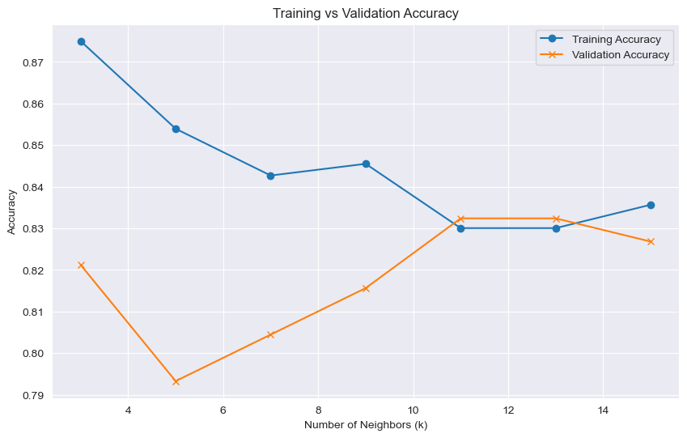

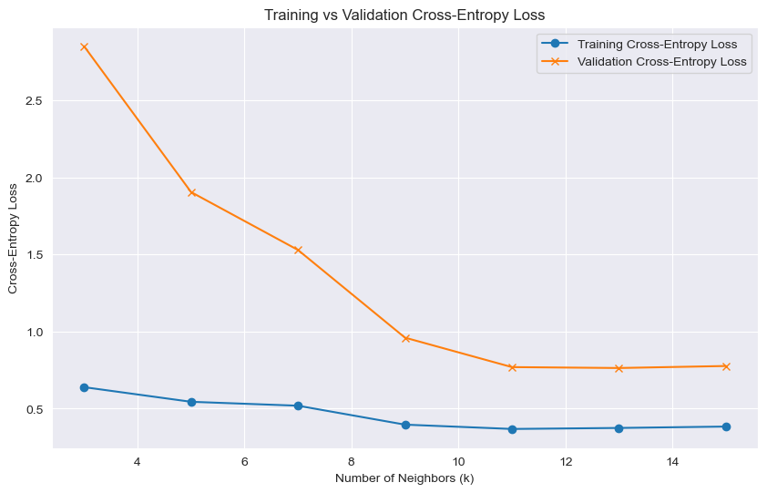

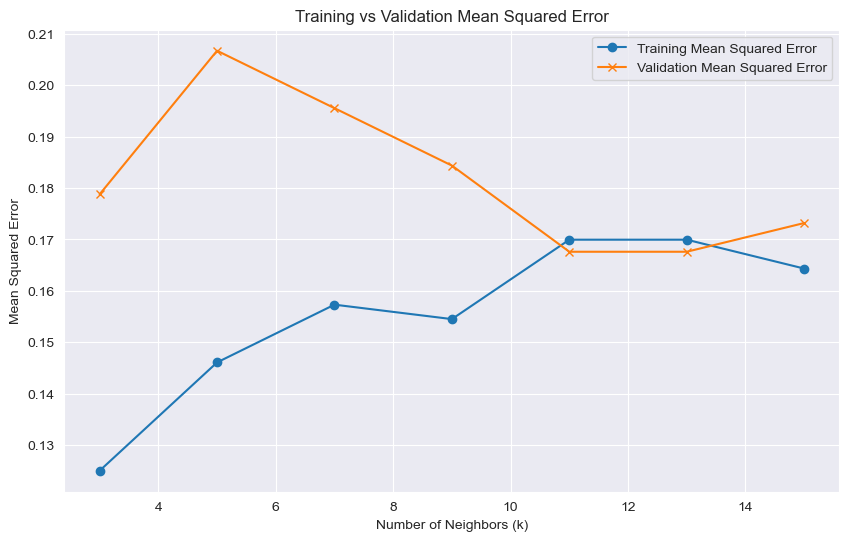

```python
X_train, X_test, y_train, y_test = train_test_split(X_encoded[backward_feature_names], y, test_size=0.2, random_state=42)

# Range of k values
k_values = [3, 5, 7, 9, 11, 13, 15]

# Evaluate KNN
train_accuracies, val_accuracies, train_losses, val_losses, train_mse, val_mse = evaluate(X_train, y_train, X_test, y_test, object=k_values , model=KNN)

# Plot Accuracy
plot(k_values, train_accuracies, val_accuracies, "Accuracy",x_label='Number of Neighbors (k)')

# Plot Cross-Entropy Loss
plot(k_values, train_losses, val_losses, "Cross-Entropy Loss" , x_label='Number of Neighbors (k)')

# Plot Mean Squared Error
plot(k_values, train_mse, val_mse, "Mean Squared Error", x_label='Number of Neighbors (k)')
```

```python
best_selection
```

```
{'backward': 0.8324022346368715}
```

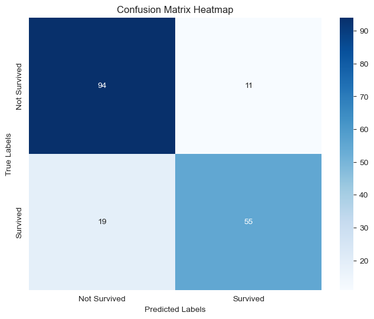

```python
# Plot the heatmap
plt.figure(figsize=(8, 6))
sns.heatmap(best_conf_matrix, annot=True, fmt='d', cmap='Blues', xticklabels=['Not Survived', 'Survived'], yticklabels=['Not Survived', 'Survived'])
plt.title("Confusion Matrix Heatmap")
plt.xlabel("Predicted Labels")
plt.ylabel("True Labels")
plt.show()
```

## NBC

Model Used: `GaussianNB`.

```python
def NBC(X_train,X_test , y_train, **args ):
    if args:
        X_train = X_train[args['param']]
        X_test = X_test[args['param']]
    # Initialize and train the Naive Bayes Classifier
    nbc_model = GaussianNB()
    nbc_model.fit(X_train, y_train)

    # Make predictions on the test set
    y_test_pred = nbc_model.predict(X_test)
    return y_test_pred , nbc_model , X_test , X_train
```

```python
best_selection , best_conf_matrix=feature_selection(NBC)
```

```
--------------backward-------------------
Accuracy: 0.7821
Precision: 0.7011
Recall: 0.8243
Specificity: 0.7524
F1-Score: 0.7578
Balanced Accuracy: 0.7884
False Positive Rate (FPR): 0.2476
--------------forward-------------------
Accuracy: 0.8156
Precision: 0.7808
Recall: 0.7703
Specificity: 0.8476
F1-Score: 0.7755
Balanced Accuracy: 0.8089
False Positive Rate (FPR): 0.1524
--------------hybrid-------------------
Accuracy: 0.8156
Precision: 0.7733
Recall: 0.7838
Specificity: 0.8381
F1-Score: 0.7785
Balanced Accuracy: 0.8109
False Positive Rate (FPR): 0.1619
```

## NBC - Graphs Training VS Validation Loss & Accuracy

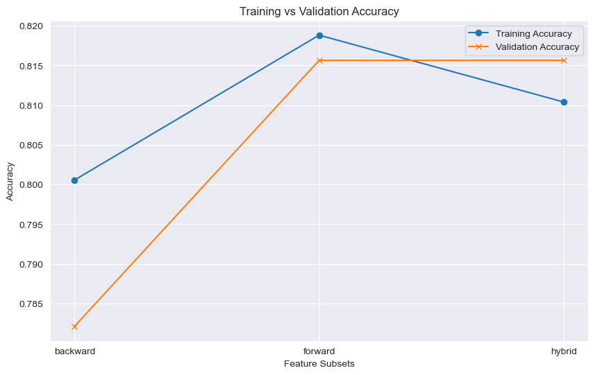

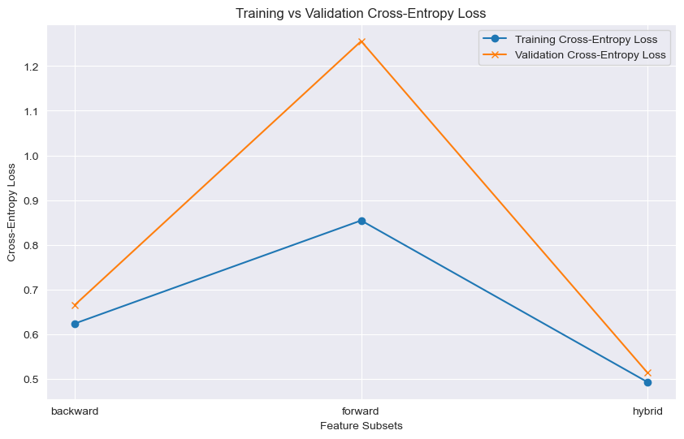

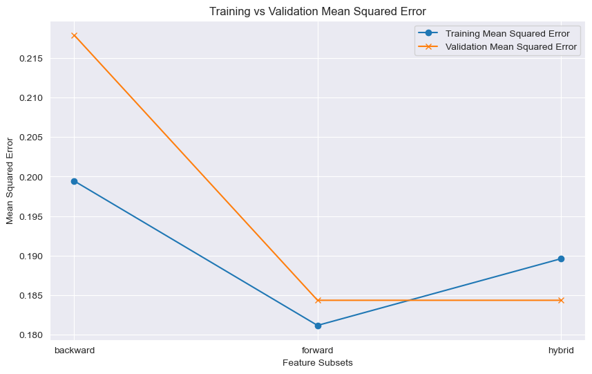

```python
feature_subsets = {'backward' : backward_feature_names , 'forward' : forward_feature_names , 'hybrid' : hybrid_feature_names}
# Evaluate
X_train, X_test, y_train, y_test = train_test_split(X_encoded, y, test_size=0.2, random_state=42)

train_accuracies, val_accuracies, train_losses, val_losses, train_mse, val_mse = evaluate(
    X_train, y_train, X_test, y_test,  object=feature_subsets.values() , model=NBC
)

# Plot Accuracy
plot(feature_subsets.keys(), train_accuracies, val_accuracies, "Accuracy",x_label='Feature Subsets')

# Plot Cross-Entropy Loss
plot(feature_subsets.keys(), train_losses, val_losses, "Cross-Entropy Loss" , x_label='Feature Subsets')

# Plot Mean Squared Error
plot(feature_subsets.keys(), train_mse, val_mse, "Mean Squared Error", x_label='Feature Subsets')
```

```python
best_selection
```

```
{'forward': 0.8156424581005587}
```

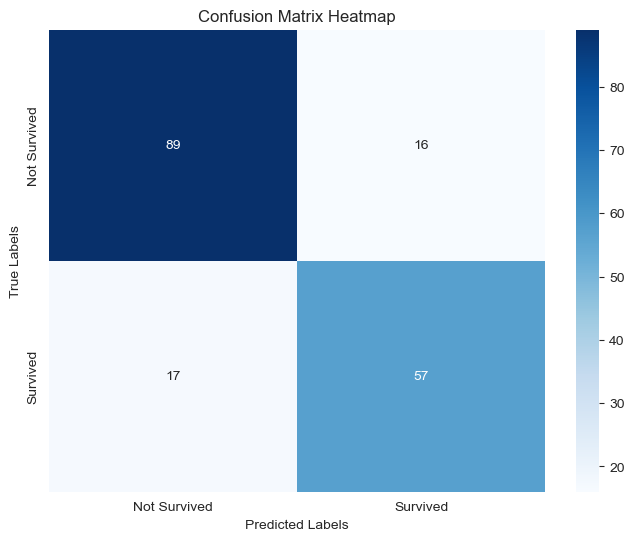

```python
# Plot the heatmap
plt.figure(figsize=(8, 6))
sns.heatmap(best_conf_matrix, annot=True, fmt='d', cmap='Blues', xticklabels=['Not Survived', 'Survived'], yticklabels=['Not Survived', 'Survived'])
plt.title("Confusion Matrix Heatmap")
plt.xlabel("Predicted Labels")
plt.ylabel("True Labels")
plt.show()
```

## Linear Discriminant Analysis (LDA)

```python
def LDA(X_train,X_test , y_train , **args):
    if args:
        X_train = X_train[args['param']]
        X_test = X_test[args['param']]
         # Align the feature sets to ensure consistency with the full set
        X_train = X_train.reindex(columns=args['full_feature_set'], fill_value=0)
        X_test = X_test.reindex(columns=args['full_feature_set'], fill_value=0)
    # Initialize and train the LDA model
    lda_model = LinearDiscriminantAnalysis()
    lda_model.fit(X_train, y_train)

    # Make predictions on the test set
    y_test_pred = lda_model.predict(X_test)
    return y_test_pred , lda_model , X_test , X_train
```

```python
best_selection , best_conf_matrix=feature_selection(LDA)
```

```
--------------backward-------------------
Accuracy: 0.8268
Precision: 0.8116
Recall: 0.7568
Specificity: 0.8762
F1-Score: 0.7832
Balanced Accuracy: 0.8165
False Positive Rate (FPR): 0.1238
--------------forward-------------------
Accuracy: 0.8212
Precision: 0.8000
Recall: 0.7568
Specificity: 0.8667
F1-Score: 0.7778
Balanced Accuracy: 0.8117
False Positive Rate (FPR): 0.1333
--------------hybrid-------------------
Accuracy: 0.8156
Precision: 0.7887
Recall: 0.7568
Specificity: 0.8571
F1-Score: 0.7724
Balanced Accuracy: 0.8069
False Positive Rate (FPR): 0.1429
```

## LDA - Graphs Training VS Validation Loss & Accuracy

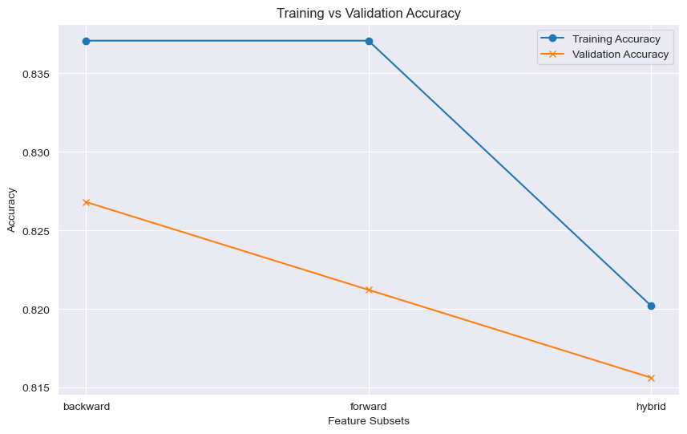

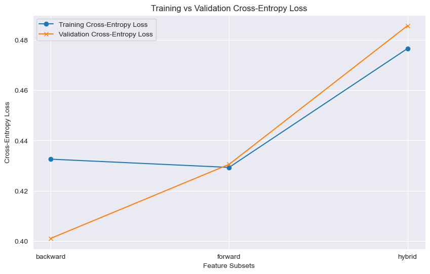

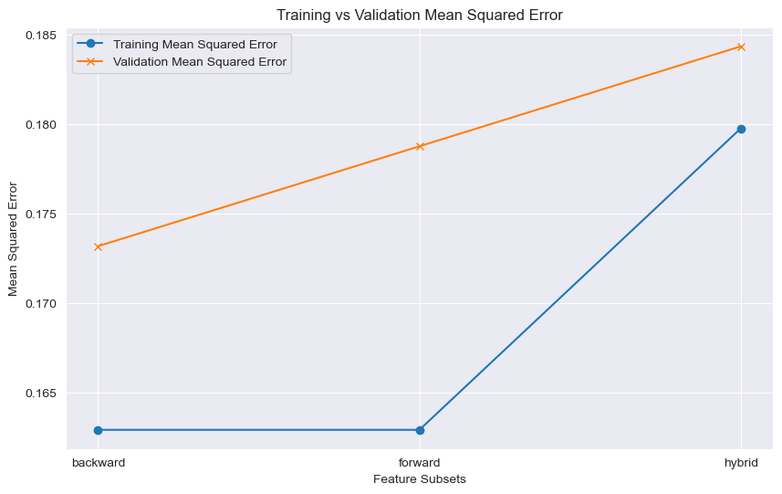

```python
feature_subsets = {'backward' : backward_feature_names , 'forward' : forward_feature_names , 'hybrid' : hybrid_feature_names}
# Evaluate
X_train, X_test, y_train, y_test = train_test_split(X_encoded, y, test_size=0.2, random_state=42)

train_accuracies, val_accuracies, train_losses, val_losses, train_mse, val_mse = evaluate(
    X_train, y_train, X_test, y_test,  object=feature_subsets.values() , model=LDA
)

# Plot Accuracy
plot(feature_subsets.keys(), train_accuracies, val_accuracies, "Accuracy",x_label='Feature Subsets')

# Plot Cross-Entropy Loss
plot(feature_subsets.keys(), train_losses, val_losses, "Cross-Entropy Loss" , x_label='Feature Subsets')

# Plot Mean Squared Error
plot(feature_subsets.keys(), train_mse, val_mse, "Mean Squared Error", x_label='Feature Subsets')
```

```python
best_selection
```

```
{'backward': 0.8268156424581006}
```

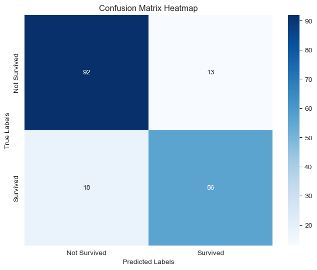

```python
# Plot the heatmap
plt.figure(figsize=(8, 6))
sns.heatmap(best_conf_matrix, annot=True, fmt='d', cmap='Blues', xticklabels=['Not Survived', 'Survived'], yticklabels=['Not Survived', 'Survived'])
plt.title("Confusion Matrix Heatmap")
plt.xlabel("Predicted Labels")
plt.ylabel("True Labels")
plt.show()
```

## Summary

[output not shown]

## Model Selection Recommendations

### 1. Backward Subset:

- **KNN** if you value overall accuracy, F1-score, and precision. It provides the best trade-off between metrics.
- **NBC** if minimizing false negatives (high recall) is a priority.

### 2. Forward Subset:

- **LDA** for the most balanced performance across all metrics.
- **NBC** as a close alternative, especially if the dataset is imbalanced and recall is critical.

### 3. Hybrid Subset:

- **NBC** for the highest recall and balanced accuracy.
- **LDA** for a more balanced trade-off between precision and recall.
- **Avoid KNN**, as its low recall makes it less suitable for this subset.

# Bibliography

This analysis was based primarily on the concepts and techniques taught in the lectures, ensuring alignment with the course material. External resources, such as Kaggle notebooks, were not directly referenced to maintain a focus on applying the learned methodologies.

## Kaggle Submission

```python
# Select features from the backward subset
X_train, X_test, y_train, y_test = train_test_split(X_encoded[backward_feature_names], y, test_size=0.2, random_state=42)

# Best k determined from cross-validation
best_k_value = 13

# Train KNN with the best k
final_knn_model = KNeighborsClassifier(n_neighbors=best_k_value)
final_knn_model.fit(X_train, y_train)

# Predict on the test set
y_test_pred = final_knn_model.predict(X_test)
```

```python
# Load and preprocess the test dataset
test_df = pd.read_csv('test.csv')

# Preprocess the test dataset (match transformations with training data)
test_df['FamilySize'] = test_df['SibSp'] + test_df['Parch'] + 1
test_df['Age'] = test_df['Age'].fillna(titanic_df['Age'].median())
test_df['Embarked'] = test_df['Embarked'].fillna(titanic_df['Embarked'].mode()[0])
test_df['Fare'] = test_df['Fare'].fillna(titanic_df['Fare'].median())
test_df['Title'] = test_df['Name'].str.extract(r' ([A-Za-z]+)\.', expand=False)
test_df['Title'] = test_df['Title'].replace(
    ['Lady', 'Countess', 'Capt', 'Col', 'Don', 'Dr', 'Major', 'Rev', 'Sir', 'Jonkheer', 'Dona'], 'Rare'
)
test_df['Title'] = test_df['Title'].replace(['Mlle', 'Ms'], 'Miss')
test_df['Title'] = test_df['Title'].replace('Mme', 'Mrs')
test_df = test_df.drop(['Name', 'Ticket', 'Cabin'], axis=1)

# Apply transformations to match training data
test_transformed = ct_enc_std.transform(test_df.drop(columns=['PassengerId']))

# Convert to DataFrame and ensure feature order matches
test_encoded = pd.DataFrame(test_transformed, columns=encoded_feature_names)

# Use only backward subset features
X_test_final = test_encoded[backward_feature_names]

# Predict survival for the test dataset
test_predictions = final_knn_model.predict(X_test_final)

# Prepare submission DataFrame
submission = pd.DataFrame({
    'PassengerId': test_df['PassengerId'],
    'Survived': test_predictions
})

# Save submission to CSV
submission.to_csv('submission.csv', index=False)
print("Submission file saved as 'submission.csv'")
```

```
Submission file saved as 'submission.csv'
```